# Week 3 Homework

Patrick

6/29/2021

### description: From data.gov: “List of every shooting incident that occurred in NYC going back to 2006 through the end of the previous calendar year. This is a breakdown of every shooting incident that occurred in NYC…”

### data: https://catalog.data.gov/dataset/nypd-shooting-incident-data-historic

```r
library(tidyverse)
library(lubridate)
url <- read_csv("https://data.cityofnewyork.us/api/views/833y-fsy8/rows.csv?accessType=DOWNLOAD")
url <- mutate(url,OCCUR_DATE = mdy(OCCUR_DATE))
nyc_inc <- url %>% select(-c(X_COORD_CD,Y_COORD_CD, Latitude, Longitude, Lon_Lat))
nyc_inc$MURDER_COUNT = ifelse(nyc_inc$STATISTICAL_MURDER_FLAG %in% c("TRUE"),1,0)
nyc_inc$INCIDENT_COUNT = ifelse(nyc_inc$STATISTICAL_MURDER_FLAG %in% c("TRUE","FALSE"),1,0)
summary(nyc_inc)
```

```
##   INCIDENT_KEY         OCCUR_DATE          OCCUR_TIME           BORO
##  Min.   :  9953245   Min.   :2006-01-01   Length:23568      Length:23568
##  1st Qu.: 55317014   1st Qu.:2008-12-30   Class1:hms        Class :character
##  Median : 83365370   Median :2012-02-26   Class2:difftime   Mode  :character
##  Mean   :102218616   Mean   :2012-10-03   Mode  :numeric
##  3rd Qu.:150772442   3rd Qu.:2016-02-28
##  Max.   :222473262   Max.   :2020-12-31
##
##     PRECINCT      JURISDICTION_CODE LOCATION_DESC      STATISTICAL_MURDER_FLAG
##  Min.   :  1.00   Min.   :0.0000    Length:23568       Mode :logical
##  1st Qu.: 44.00   1st Qu.:0.0000    Class :character   FALSE:19080
##  Median : 69.00   Median :0.0000    Mode  :character   TRUE :4488
##  Mean   : 66.21   Mean   :0.3323
##  3rd Qu.: 81.00   3rd Qu.:0.0000
##  Max.   :123.00   Max.   :2.0000
##                   NA's   :2
##  PERP_AGE_GROUP       PERP_SEX          PERP_RACE         VIC_AGE_GROUP
##  Length:23568       Length:23568       Length:23568       Length:23568
##  Class :character   Class :character   Class :character   Class :character
##  Mode  :character   Mode  :character   Mode  :character   Mode  :character
##
##
##
##
##    VIC_SEX            VIC_RACE          MURDER_COUNT    INCIDENT_COUNT
##  Length:23568       Length:23568       Min.   :0.0000   Min.   :1
##  Class :character   Class :character   1st Qu.:0.0000   1st Qu.:1
##  Mode  :character   Mode  :character   Median :0.0000   Median :1
##                                        Mean   :0.1904   Mean   :1
##                                        3rd Qu.:0.0000   3rd Qu.:1
##                                        Max.   :1.0000   Max.   :1
##
```

### First, I found that looking back at incidents from many years ago is not beneficial, if I were an analyst for the police department. So in the 1st visual I found that there was a spike in incidents and murders in 2020.

### In the 2nd visual, I see that there are a lot more incidents and murders in the Bronx and Brooklyn.

### In the 3rd visual, I have the incidents and murders aggregated by precinct in case the chief of police would like to use this data to assign the right amount of resources.

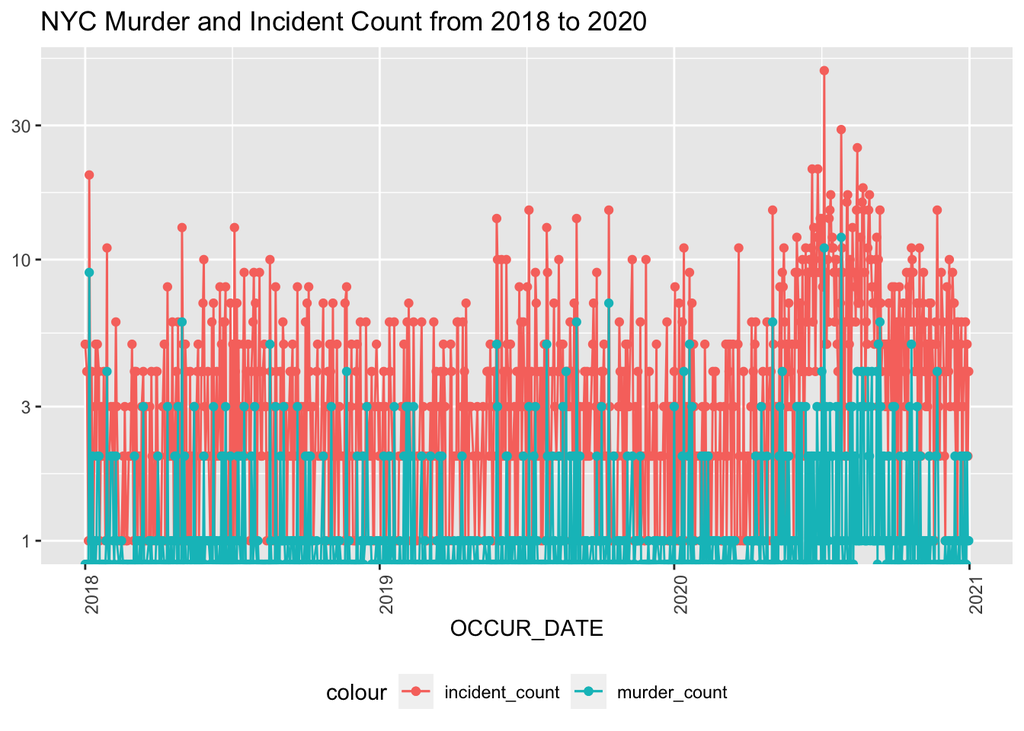

```r
nyc_inc_by_date <- nyc_inc %>% group_by(OCCUR_DATE) %>% summarize (INCIDENT_COUNT = sum(INCIDENT_COUNT), MURDER_COUNT = sum(MURDER_COUNT)) %>% select(OCCUR_DATE, INCIDENT_COUNT, MURDER_COUNT) %>% ungroup()

nyc_inc_by_date %>% filter(OCCUR_DATE >= as.Date("2018-01-01")) %>% ggplot(aes(x = OCCUR_DATE, y= INCIDENT_COUNT)) + geom_line(aes(color = "incident_count")) + geom_point(aes(color = "incident_count")) + geom_line(aes(y = MURDER_COUNT, color = "murder_count")) + geom_point(aes(y= MURDER_COUNT, color = "murder_count")) + scale_y_log10() + theme(legend.position = "bottom", axis.text.x = element_text(angle = 90)) + labs(title = "NYC Murder and Incident Count from 2018 to 2020", y = NULL)
```

```
## geom_path: Each group consists of only one observation. Do you need to adjust
## the group aesthetic?
## geom_path: Each group consists of only one observation. Do you need to adjust
## the group aesthetic?
```

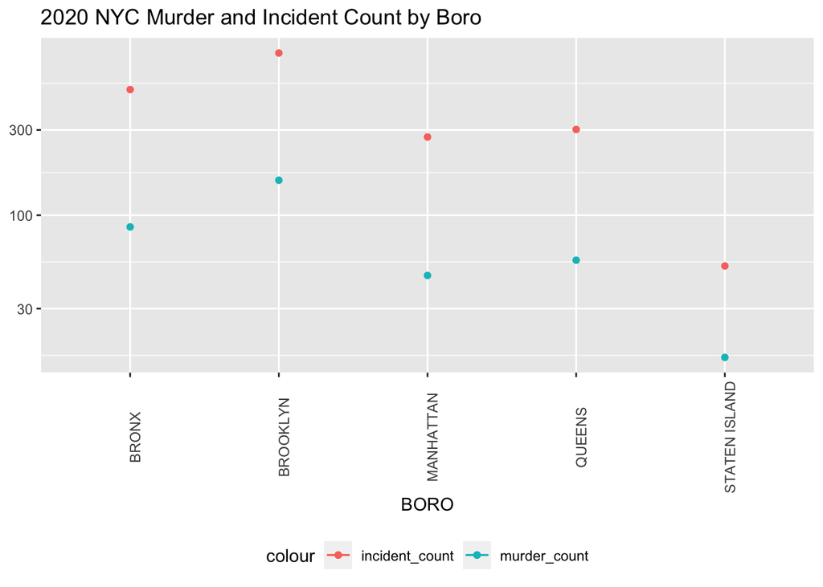

```r
nyc_inc_by_boro <- nyc_inc %>% filter(OCCUR_DATE >= as.Date("2020-01-01")) %>% group_by(BORO) %>% summarize (INCIDENT_COUNT = sum(INCIDENT_COUNT), MURDER_COUNT = sum(MURDER_COUNT)) %>% select(BORO, INCIDENT_COUNT, MURDER_COUNT) %>% ungroup()

nyc_inc_by_boro %>% ggplot(aes(x = BORO, y= INCIDENT_COUNT)) + geom_line(aes(color = "incident_count")) + geom_point(aes(color = "incident_count")) + geom_line(aes(y = MURDER_COUNT, color = "murder_count")) + geom_point(aes(y= MURDER_COUNT, color = "murder_count")) + scale_y_log10() + theme(legend.position = "bottom", axis.text.x = element_text(angle = 90)) + labs(title = "2020 NYC Murder and Incident Count by Boro", y = NULL)
```

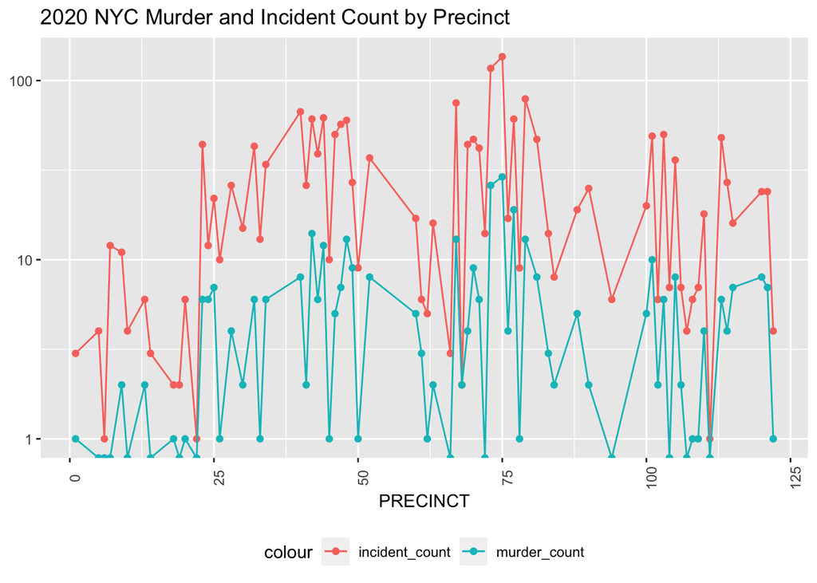

```r
nyc_inc_by_prec <- nyc_inc %>% filter(OCCUR_DATE >= as.Date("2020-01-01")) %>% group_by(PRECINCT) %>% summarize (INCIDENT_COUNT = sum(INCIDENT_COUNT), MURDER_COUNT = sum(MURDER_COUNT)) %>% select(PRECINCT, INCIDENT_COUNT, MURDER_COUNT) %>% ungroup()

nyc_inc_by_prec %>% ggplot(aes(x = PRECINCT, y= INCIDENT_COUNT)) + geom_line(aes(color = "incident_count")) + geom_point(aes(color = "incident_count")) + geom_line(aes(y = MURDER_COUNT, color = "murder_count")) + geom_point(aes(y= MURDER_COUNT, color = "murder_count")) + scale_y_log10() + theme(legend.position = "bottom", axis.text.x = element_text(angle = 90)) + labs(title = "2020 NYC Murder and Incident Count by Precinct", y = NULL)
```

### In the model below, at the precinct level, you can see that there is a strong correlation between incidents and murders.

```r
mod <- lm(MURDER_COUNT ~ INCIDENT_COUNT, data = nyc_inc_by_prec)
summary(mod)
```

```
##
## Call:
## lm(formula = MURDER_COUNT ~ INCIDENT_COUNT, data = nyc_inc_by_prec)
##
## Residuals:
##     Min      1Q  Median      3Q     Max
## -4.7491 -1.0107 -0.0035  1.0309  7.4095
##
## Coefficients:
##                 Estimate Std. Error t value Pr(>|t|)
## (Intercept)    -0.189603   0.355341  -0.534    0.595
## INCIDENT_COUNT  0.193116   0.009525  20.274   <2e-16 ***
## ---
## Signif. codes:  0 '***' 0.001 '**' 0.01 '*' 0.05 '.' 0.1 ' ' 1
##
## Residual standard error: 2.173 on 72 degrees of freedom
## Multiple R-squared:  0.8509, Adjusted R-squared:  0.8489
## F-statistic:   411 on 1 and 72 DF,  p-value: < 2.2e-16
```

```r
nyc_inc_by_prec %>% mutate(pred = predict(mod))
```

```
## # A tibble: 74 x 4
##    PRECINCT INCIDENT_COUNT MURDER_COUNT    pred
##       <dbl>          <dbl>        <dbl>   <dbl>
##  1        1              3            1 0.390
##  2        5              4            0 0.583
##  3        6              1            0 0.00351
##  4        7             12            0 2.13
##  5        9             11            2 1.93
##  6       10              4            0 0.583
##  7       13              6            2 0.969
##  8       14              3            0 0.390
##  9       18              2            1 0.197
## 10       19              2            0 0.197
## # … with 64 more rows
```

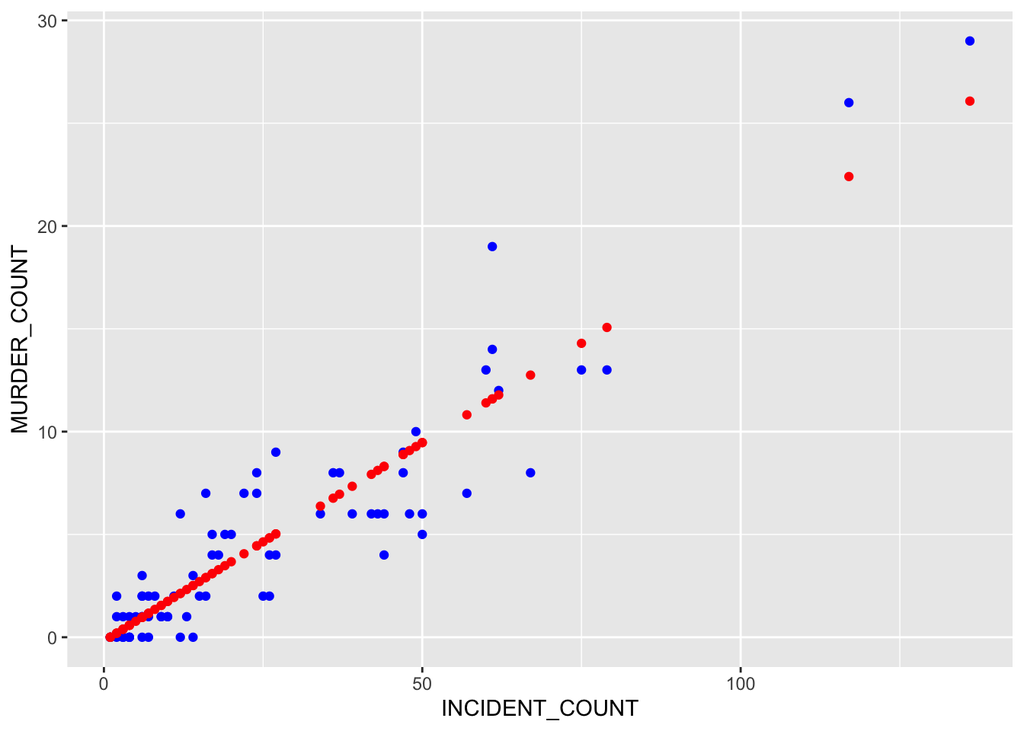

```r
nyc_inc_w_pred <- nyc_inc_by_prec %>% mutate(pred = predict(mod))
nyc_inc_w_pred %>% ggplot() + geom_point(aes(x = INCIDENT_COUNT, y = MURDER_COUNT), color = "blue") + geom_point(aes(x = INCIDENT_COUNT, y = pred), color = "red")
```

### In conclusion, because of the spike in shooting incidents and murders in 2020, I suggest the chief of police look at allocating the appropriate amount of resources in the precincts in the below table. Finally, when it comes to bias, I decided not to look at age and race of the perpetrator. Also, the data for age and race were not consistent and in some cases was missing.

```r
data <- nyc_inc_by_prec[order(nyc_inc_by_prec[,"INCIDENT_COUNT"],decreasing = TRUE),]
data
```

```
## # A tibble: 74 x 3
##    PRECINCT INCIDENT_COUNT MURDER_COUNT
##       <dbl>          <dbl>        <dbl>
##  1       75            136           29
##  2       73            117           26
##  3       79             79           13
##  4       67             75           13
##  5       40             67            8
##  6       44             62           12
##  7       42             61           14
##  8       77             61           19
##  9       48             60           13
## 10       47             57            7
## # … with 64 more rows
```